# HW12

2023-11-28

In this data set, renal.csv, we have urine samples for 40 dogs. It contains sodium samples contained once before (x) the administration of Mercuhydrin and once after (y). The first 10 dogs in this data set are the control group who were not administer with any Mercuhydrin and two samples were taken in different time periods. The remaining 30 dogs were administered this medication to see the difference in sodium levels in the kidneys post medication.

## Normality

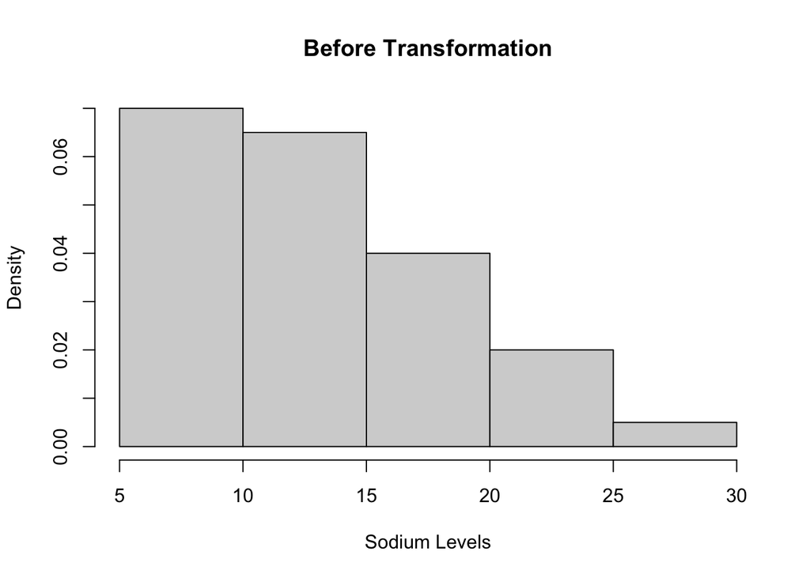

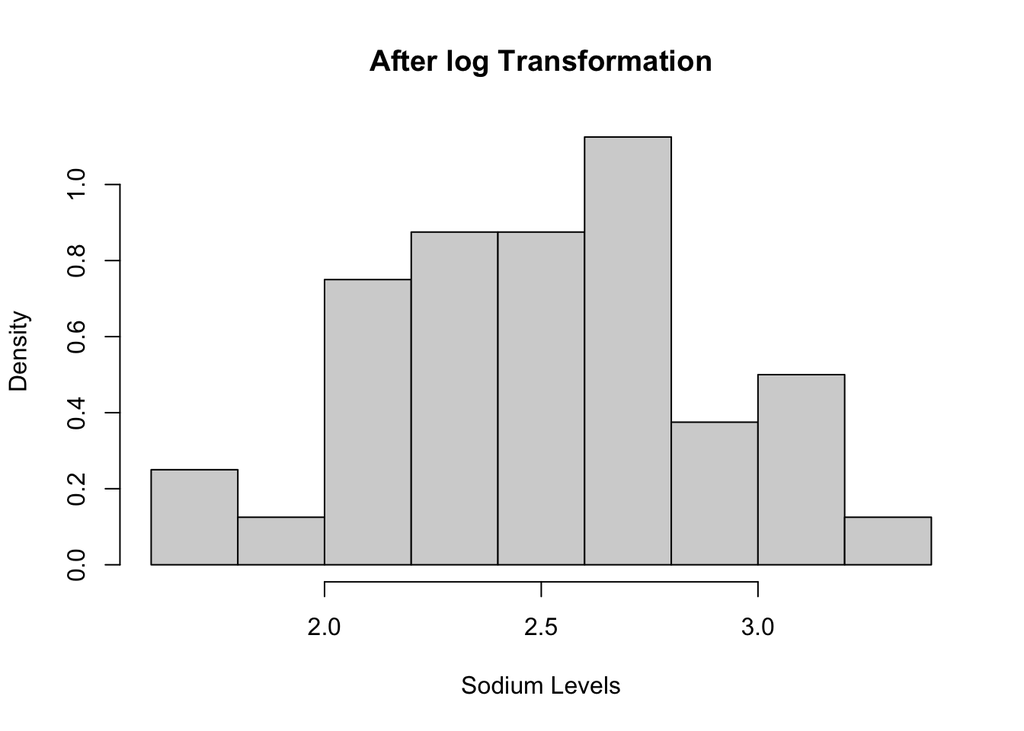

```r
renal$y_log <- log(renal$y)
renal$x_log <- log(renal$x)
renal$grp_dummy <- as.factor(renal$grp)

shapiro_test(renal$y)
```

```
## # A tibble: 1 × 3
##   variable statistic p.value
##   <chr>        <dbl>   <dbl>
## 1 renal$y      0.937  0.0274
```

```r
shapiro_test(renal$y_log)
```

```
## # A tibble: 1 × 3
##   variable    statistic p.value
##   <chr>           <dbl>   <dbl>
## 1 renal$y_log     0.986   0.902
```

## Fitting the Model With Interaction

*y* = $\beta$<sub>0</sub> + $\beta$<sub>1</sub>*X*<sub>1</sub> + $\beta$<sub>2</sub>*X*<sub>2</sub> + $\gamma$*X*<sub>1</sub>*X*<sub>2</sub>

Fitting the model based on the log transformation of the data with the purpose of evaluating relationships, the efficiency of the medication, and the statistical significance of certain aspects of the data. Specifically looking at the interaction of x_log:grp is considered statistically significant in order to reject the null hypothesis or not.

H<sub>0</sub>: $\gamma$ = 0

```r
model_inter <- lm(y_log ~ x_log * grp_dummy, data = renal)
summary(model_inter)
```

```
##
## Call:
## lm(formula = y_log ~ x_log * grp_dummy, data = renal)
##
## Residuals:
##      Min       1Q   Median       3Q      Max
## -0.70776 -0.16954  0.00405  0.23691  0.75158
##
## Coefficients:
##                  Estimate Std. Error t value Pr(>|t|)
## (Intercept)        1.7411     0.6609   2.635   0.0123 *
## x_log              0.2565     0.2969   0.864   0.3933
## grp_dummy1        -0.7318     0.8004  -0.914   0.3666
## x_log:grp_dummy1   0.4325     0.3571   1.211   0.2338
## ---
## Signif. codes:  0 '***' 0.001 '**' 0.01 '*' 0.05 '.' 0.1 ' ' 1
##
## Residual standard error: 0.318 on 36 degrees of freedom
## Multiple R-squared:  0.3301, Adjusted R-squared:  0.2742
## F-statistic: 5.912 on 3 and 36 DF,  p-value: 0.00218
```

**Interaction:** The interaction coefficient for x_log:grp is 0.4325 with a p-value of 0.2338.This indicates no significant interactions between the baseline (x) and the groups (control vs. medicated). The interaction is considered not statistically significant, so we cannot reject the null hypothesis based of these results.

```r
anova(model_inter)
```

```
## Analysis of Variance Table
##
## Response: y_log
##                 Df Sum Sq Mean Sq F value   Pr(>F)
## x_log            1 1.2603 1.26031 12.4668 0.001155 **
## grp_dummy        1 0.3845 0.38453  3.8037 0.058957 .
## x_log:grp_dummy  1 0.1483 0.14826  1.4666 0.233780
## Residuals       36 3.6393 0.10109
## ---
## Signif. codes:  0 '***' 0.001 '**' 0.01 '*' 0.05 '.' 0.1 ' ' 1
```

## Fitting the Model Without Interaction

*y* = $\beta$<sub>0</sub> + $\beta$<sub>1</sub>*X*<sub>1</sub> + $\beta$<sub>2</sub>*X*<sub>2</sub> + $\epsilon$

H<sub>0</sub>: $\beta$<sub>1</sub> = 0 or H<sub>0</sub>: $\beta$<sub>2</sub> = 0

```r
model_no_inter <- lm(y_log ~ x_log + grp_dummy, data = renal)
summary(model_no_inter)
```

```
##
## Call:
## lm(formula = y_log ~ x_log + grp_dummy, data = renal)
##
## Residuals:
##      Min       1Q   Median       3Q      Max
## -0.85353 -0.18129 -0.01296  0.19867  0.71759
##
## Coefficients:
##             Estimate Std. Error t value Pr(>|t|)
## (Intercept)   1.0835     0.3791   2.858  0.00695 **
## x_log         0.5554     0.1660   3.345  0.00190 **
## grp_dummy1    0.2271     0.1172   1.938  0.06027 .
## ---
## Signif. codes:  0 '***' 0.001 '**' 0.01 '*' 0.05 '.' 0.1 ' ' 1
##
## Residual standard error: 0.3199 on 37 degrees of freedom
## Multiple R-squared:  0.3028, Adjusted R-squared:  0.2651
## F-statistic: 8.034 on 2 and 37 DF,  p-value: 0.001266
```

**Results:** The coefficient for x_log was 0.5554 with a p-value of 0.00190.This indicates that x_log is statistically significant to y_log. The coefficient for grp or group is 0.2271 with a p-value of 0.06027. This indicates that there is a weak relationship between group and y_log (post-baseline) as its not statistically significant enough as the p-value is just above 0.05.

**H<sub>0</sub>: $\beta$<sub>1</sub> = 0**

The null hypothesis looks at the initial sodium levels in the dogs urine (baseline or x) to see if it has impacts on the sodium levels after the medication was administered. The baseline is statistically significant with a p-value of 0.00190, indicating the rejection of the null hypothesis. Demonstrating that there is a relationship between the baseline (x) and the post-baseline(y).

**H<sub>0</sub>: $\beta$<sub>2</sub> = 0**

The null hypothesis looks at the impact on the sodium level post-baseline (y) compared to the control or the medicated groups. The groups p-value was 0.06027, which indicates that there is a weak relationship but not enough to make it statistically significant. As a result, we cannot reject this null hypothesis and our results have shown that the relationship between the post-baseline sodium level and the medication are not strong enough.